# Unsupervised Learning: Trade&Ahead

**Marks: 60**

### Context

The stock market has consistently proven to be a good place to invest in and save for the future. There are a lot of compelling reasons to invest in stocks. It can help in fighting inflation, create wealth, and also provides some tax benefits. Good steady returns on investments over a long period of time can also grow a lot more than seems possible. Also, thanks to the power of compound interest, the earlier one starts investing, the larger the corpus one can have for retirement. Overall, investing in stocks can help meet life's financial aspirations.

It is important to maintain a diversified portfolio when investing in stocks in order to maximise earnings under any market condition. Having a diversified portfolio tends to yield higher returns and face lower risk by tempering potential losses when the market is down. It is often easy to get lost in a sea of financial metrics to analyze while determining the worth of a stock, and doing the same for a multitude of stocks to identify the right picks for an individual can be a tedious task. By doing a cluster analysis, one can identify stocks that exhibit similar characteristics and ones which exhibit minimum correlation. This will help investors better analyze stocks across different market segments and help protect against risks that could make the portfolio vulnerable to losses.

### Objective

Trade&Ahead is a financial consultancy firm who provide their customers with personalized investment strategies. They have hired you as a Data Scientist and provided you with data comprising stock price and some financial indicators for a few companies listed under the New York Stock Exchange. They have assigned you the tasks of analyzing the data, grouping the stocks based on the attributes provided, and sharing insights about the characteristics of each group.

### Data Dictionary

- Ticker Symbol: An abbreviation used to uniquely identify publicly traded shares of a particular stock on a particular stock market
- Company: Name of the company
- GICS Sector: The specific economic sector assigned to a company by the Global Industry Classification Standard (GICS) that best defines its business operations
- GICS Sub Industry: The specific sub-industry group assigned to a company by the Global Industry Classification Standard (GICS) that best defines its business operations
- Current Price: Current stock price in dollars
- Price Change: Percentage change in the stock price in 13 weeks
- Volatility: Standard deviation of the stock price over the past 13 weeks
- ROE: A measure of financial performance calculated by dividing net income by shareholders' equity (shareholders' equity is equal to a company's assets minus its debt)
- Cash Ratio: The ratio of a company's total reserves of cash and cash equivalents to its total current liabilities
- Net Cash Flow: The difference between a company's cash inflows and outflows (in dollars)
- Net Income: Revenues minus expenses, interest, and taxes (in dollars)
- Earnings Per Share: Company's net profit divided by the number of common shares it has outstanding (in dollars)
- Estimated Shares Outstanding: Company's stock currently held by all its shareholders
- P/E Ratio: Ratio of the company's current stock price to the earnings per share
- P/B Ratio: Ratio of the company's stock price per share by its book value per share (book value of a company is the net difference between that company's total assets and total liabilities)

## Importing necessary libraries and data

```python
# for reading and manipulating data
import numpy as np
import pandas as pd
```

```python
# for data visualization
import matplotlib.pyplot as plt
import seaborn as sns
```

```python
# for scaleing the data using z-score
from sklearn.preprocessing import StandardScaler
```

```python
# for computng distances
from scipy.spatial.distance import cdist, pdist
```

```python
# for performing k-means clustering and computing silhouette scores
from sklearn.cluster import KMeans
from sklearn.metrics import silhouette_score
```

```python
# for performing hierarchical clustering, computing cophenetic correlation, and creating dendrograms
from sklearn.cluster import AgglomerativeClustering
from scipy.cluster.hierarchy import dendrogram, linkage, cophenet
```

```python
# for performing PCA
from sklearn.decomposition import PCA
```

```python
!pip install yellowbrick
# for visualizing the elbow curve and silhouette scores
from yellowbrick.cluster import KElbowVisualizer, SilhouetteVisualizer
```

```python
#for formating numeric data for easier readability
pd.set_option(
    "display.float_format", lambda x: "%.2f" % x
)
# this displays the numbers rounded off to 2 decimal places
```

```python
# for removing the limit for the number of displayed columns
pd.set_option("display.max_columns", None)

# for Setting the limit for the number of displayed rows
pd.set_option("display.max_rows", 200)
```

```python
# for supressing warnings
import warnings
warnings.filterwarnings("ignore")
```

## Data Overview

- Observations
- Sanity checks

```python
# loading the dataset
stock_data = pd.read_csv('stock_data.csv')
```

```python
# copying the dataset to perform manipulations
data = stock_data.copy()
```

```python
data.head()
```

|  | Ticker Symbol | Security | GICS Sector | GICS Sub Industry | Current Price | Price Change | Volatility | ROE | Cash Ratio | Net Cash Flow | Net Income | Earnings Per Share | Estimated Shares Outstanding | P/E Ratio | P/B Ratio |
| --- | --- | --- | --- | --- | --- | --- | --- | --- | --- | --- | --- | --- | --- | --- | --- |
| 0 | AAL | American Airlines Group | Industrials | Airlines | 42.35 | 10.00 | 1.69 | 135 | 51 | -604000000 | 7610000000 | 11.39 | 668129938.50 | 3.72 | -8.78 |
| 1 | ABBV | AbbVie | Health Care | Pharmaceuticals | 59.24 | 8.34 | 2.20 | 130 | 77 | 51000000 | 5144000000 | 3.15 | 1633015873.00 | 18.81 | -8.75 |
| 2 | ABT | Abbott Laboratories | Health Care | Health Care Equipment | 44.91 | 11.30 | 1.27 | 21 | 67 | 938000000 | 4423000000 | 2.94 | 1504421769.00 | 15.28 | -0.39 |
| 3 | ADBE | Adobe Systems Inc | Information Technology | Application Software | 93.94 | 13.98 | 1.36 | 9 | 180 | -240840000 | 629551000 | 1.26 | 499643650.80 | 74.56 | 4.20 |
| 4 | ADI | Analog Devices, Inc. | Information Technology | Semiconductors | 55.32 | -1.83 | 1.70 | 14 | 272 | 315120000 | 696878000 | 0.31 | 2247993548.00 | 178.45 | 1.06 |

```python
data.shape
```

```
(340, 15)
```

- **There are 340 rows and 15 columns in the data set.**

```python
data.info()
```

```
<class 'pandas.core.frame.DataFrame'>
RangeIndex: 340 entries, 0 to 339
Data columns (total 15 columns):
 #   Column                        Non-Null Count  Dtype
---  ------                        --------------  -----
 0   Ticker Symbol                 340 non-null    object
 1   Security                      340 non-null    object
 2   GICS Sector                   340 non-null    object
 3   GICS Sub Industry             340 non-null    object
 4   Current Price                 340 non-null    float64
 5   Price Change                  340 non-null    float64
 6   Volatility                    340 non-null    float64
 7   ROE                           340 non-null    int64
 8   Cash Ratio                    340 non-null    int64
 9   Net Cash Flow                 340 non-null    int64
 10  Net Income                    340 non-null    int64
 11  Earnings Per Share            340 non-null    float64
 12  Estimated Shares Outstanding  340 non-null    float64
 13  P/E Ratio                     340 non-null    float64
 14  P/B Ratio                     340 non-null    float64
dtypes: float64(7), int64(4), object(4)
memory usage: 40.0+ KB
```

- **There are no missing values in the dataset.**
- **Ticker Symbol, Security, GICS Sector, GICS Sub Industry have datatype Object.**
- **Current Price, Price Change, Volatility, Earnings Per Share, Estimated Shares Outstanding, P/E Ratio, P/B Ratio have datatype float.**
- **ROE, Cash Ratio, Net Cash Flow, Net Income have datatype integer.**

**We wil convert the 'Object' datatype to 'Category' datatype. This will help us reduce the size of the file and conserve memory.**

```python
# converting all columns with dtype object into category
for col in data.columns[data.dtypes=='object']:
    data[col] = data[col].astype('category')
```

```python
data.info()
```

```
<class 'pandas.core.frame.DataFrame'>
RangeIndex: 340 entries, 0 to 339
Data columns (total 15 columns):
 #   Column                        Non-Null Count  Dtype
---  ------                        --------------  -----
 0   Ticker Symbol                 340 non-null    category
 1   Security                      340 non-null    category
 2   GICS Sector                   340 non-null    category
 3   GICS Sub Industry             340 non-null    category
 4   Current Price                 340 non-null    float64
 5   Price Change                  340 non-null    float64
 6   Volatility                    340 non-null    float64
 7   ROE                           340 non-null    int64
 8   Cash Ratio                    340 non-null    int64
 9   Net Cash Flow                 340 non-null    int64
 10  Net Income                    340 non-null    int64
 11  Earnings Per Share            340 non-null    float64
 12  Estimated Shares Outstanding  340 non-null    float64
 13  P/E Ratio                     340 non-null    float64
 14  P/B Ratio                     340 non-null    float64
dtypes: category(4), float64(7), int64(4)
memory usage: 58.1 KB
```

- **The object datatype is changed to categorical variable now.**

**The column 'Ticker Symbol' is not of much use in our analysis ; hence we will drop it from the data set.**

```python
# dropping the ticker symbol column
data.drop("Ticker Symbol", axis=1, inplace=True)
```

```python
data.head()
```

|  | Security | GICS Sector | GICS Sub Industry | Current Price | Price Change | Volatility | ROE | Cash Ratio | Net Cash Flow | Net Income | Earnings Per Share | Estimated Shares Outstanding | P/E Ratio | P/B Ratio |
| --- | --- | --- | --- | --- | --- | --- | --- | --- | --- | --- | --- | --- | --- | --- |
| 0 | American Airlines Group | Industrials | Airlines | 42.35 | 10.00 | 1.69 | 135 | 51 | -604000000 | 7610000000 | 11.39 | 668129938.50 | 3.72 | -8.78 |
| 1 | AbbVie | Health Care | Pharmaceuticals | 59.24 | 8.34 | 2.20 | 130 | 77 | 51000000 | 5144000000 | 3.15 | 1633015873.00 | 18.81 | -8.75 |
| 2 | Abbott Laboratories | Health Care | Health Care Equipment | 44.91 | 11.30 | 1.27 | 21 | 67 | 938000000 | 4423000000 | 2.94 | 1504421769.00 | 15.28 | -0.39 |
| 3 | Adobe Systems Inc | Information Technology | Application Software | 93.94 | 13.98 | 1.36 | 9 | 180 | -240840000 | 629551000 | 1.26 | 499643650.80 | 74.56 | 4.20 |
| 4 | Analog Devices, Inc. | Information Technology | Semiconductors | 55.32 | -1.83 | 1.70 | 14 | 272 | 315120000 | 696878000 | 0.31 | 2247993548.00 | 178.45 | 1.06 |

## Exploratory Data Analysis (EDA)

- EDA is an important part of any project involving data.
- It is important to investigate and understand the data better before building a model with it.
- A few questions have been mentioned below which will help you approach the analysis in the right manner and generate insights from the data.
- A thorough analysis of the data, in addition to the questions mentioned below, should be done.

**Questions**:

1. What does the distribution of stock prices look like?
2. The stocks of which economic sector have seen the maximum price increase on average?
3. How are the different variables correlated with each other?
4. Cash ratio provides a measure of a company's ability to cover its short-term obligations using only cash and cash equivalents. How does the average cash ratio vary across economic sectors?
5. P/E ratios can help determine the relative value of a company's shares as they signify the amount of money an investor is willing to invest in a single share of a company per dollar of its earnings. How does the P/E ratio vary, on average, across economic sectors?

```python
#provide statistical summary of all categorical columns
data.describe().T
```

|  | count | mean | std | min | 25% | 50% | 75% | max |
| --- | --- | --- | --- | --- | --- | --- | --- | --- |
| Current Price | 340.00 | 80.86 | 98.06 | 4.50 | 38.55 | 59.70 | 92.88 | 1274.95 |
| Price Change | 340.00 | 4.08 | 12.01 | -47.13 | -0.94 | 4.82 | 10.70 | 55.05 |
| Volatility | 340.00 | 1.53 | 0.59 | 0.73 | 1.13 | 1.39 | 1.70 | 4.58 |
| ROE | 340.00 | 39.60 | 96.55 | 1.00 | 9.75 | 15.00 | 27.00 | 917.00 |
| Cash Ratio | 340.00 | 70.02 | 90.42 | 0.00 | 18.00 | 47.00 | 99.00 | 958.00 |
| Net Cash Flow | 340.00 | 55537620.59 | 1946365312.18 | -11208000000.00 | -193906500.00 | 2098000.00 | 169810750.00 | 20764000000.00 |
| Net Income | 340.00 | 1494384602.94 | 3940150279.33 | -23528000000.00 | 352301250.00 | 707336000.00 | 1899000000.00 | 24442000000.00 |
| Earnings Per Share | 340.00 | 2.78 | 6.59 | -61.20 | 1.56 | 2.90 | 4.62 | 50.09 |
| Estimated Shares Outstanding | 340.00 | 577028337.75 | 845849595.42 | 27672156.86 | 158848216.10 | 309675137.80 | 573117457.32 | 6159292035.00 |
| P/E Ratio | 340.00 | 32.61 | 44.35 | 2.94 | 15.04 | 20.82 | 31.76 | 528.04 |
| P/B Ratio | 340.00 | -1.72 | 13.97 | -76.12 | -4.35 | -1.07 | 3.92 | 129.06 |

```python
#provide statistical summary of all categorical columns
data.describe(include='category').T
```

|  | count | unique | top | freq |
| --- | --- | --- | --- | --- |
| Security | 340 | 340 | 3M Company | 1 |
| GICS Sector | 340 | 11 | Industrials | 53 |
| GICS Sub Industry | 340 | 104 | Oil & Gas Exploration & Production | 16 |

```python
# function to create labeled barplots


def labeled_barplot(data, feature, perc=False, n=None):
    """
    Barplot with percentage at the top

    data: dataframe
    feature: dataframe column
    perc: whether to display percentages instead of count (default is False)
    n: displays the top n category levels (default is None, i.e., display all levels)
    """

    total = len(data[feature])  # length of the column
    count = data[feature].nunique()
    if n is None:
        plt.figure(figsize=(count + 1, 5))
    else:
        plt.figure(figsize=(n + 1, 5))

    plt.xticks(rotation=90, fontsize=12)
    ax = sns.countplot(
        data=data,
        x=feature,
        palette="summer",
        order=data[feature].value_counts().index[:n].sort_values(),
    )

    for p in ax.patches:
        if perc == True:
            label = "{:.1f}%".format(
                100 * p.get_height() / total
            )  # percentage of each class of the category
        else:
            label = p.get_height()  # count of each level of the category

        x = p.get_x() + p.get_width() / 2  # width of the plot
        y = p.get_height()  # height of the plot

        ax.annotate(
            label,
            (x, y),
            ha="center",
            va="center",
            size=12,
            xytext=(0, 5),
            textcoords="offset points",
        )  # annotate the percentage

    plt.show()  # show the plot
```

```python
# function to plot a boxplot and a histogram along the same scale

def histogram_boxplot(data, feature, figsize=(16, 6), kde=False, bins=None, hue=None):
    """
    Combines boxplot and histogram

    data: dataframe
    feature: dataframe column
    figsize: size of figure (default (16,6))
    kde: whether to show the density curve (default False)
    bins: number of bins for histogram (default None)
    """
    f2, (ax_box2, ax_hist2) = plt.subplots(
        nrows=2,  # Number of rows of the subplot grid= 2
        sharex=True,  # x-axis will be shared among all subplots
        gridspec_kw={"height_ratios": (0.25, 0.75)},
        figsize=figsize,
    )  # creating the 2 subplots
    sns.boxplot(
        data=data, x=feature, ax=ax_box2, showmeans=True,
    )  # boxplot will be created and a star will indicate the mean value of the column
    sns.histplot(
        data=data, x=feature, kde=kde, ax=ax_hist2, bins=bins, palette = 'winter'
    ) if bins else sns.histplot(
        data=data, x=feature, kde=kde, ax=ax_hist2
    )  # For histogram
    ax_hist2.axvline(
        data[feature].mean(), color="green", linestyle="--"
    )  # Add mean to the histogram
    ax_hist2.axvline(
        data[feature].median(), color="black", linestyle="-"
    )  # Add median to the histogram
```

### Sector Wise Analysis (GICS Sector)

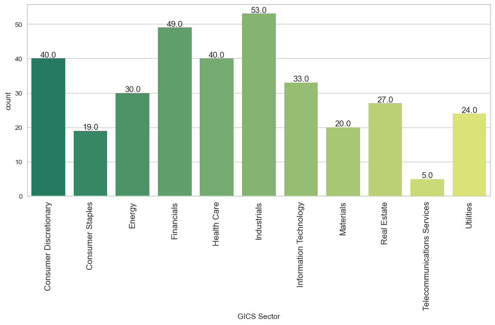

```python
#creating labeled barplot of stocks by sector
labeled_barplot(data, 'GICS Sector')
```

```python
# displaying the top five sectors with the most number of stocks
data["GICS Sector"].value_counts().head(n=5)
```

```
GICS Sector
Industrials               53
Financials                49
Consumer Discretionary    40
Health Care               40
Information Technology    33
Name: count, dtype: int64
```

- **There are 11 different industrial sectors in the data set**
- **The top sectors in terms of frequency are 'Industrials', 'Financials', 'Consumer Discretionary', 'Health Care', 'Information Technology'.**

### Sub-Industry analysis

[figure not shown]

```python
#creating labeled barplot of stocks by sub industry
labeled_barplot(data, 'GICS Sub Industry')
```

```python
# Top five sub industries with the most number of stocks
data['GICS Sub Industry'].value_counts().head(n=5)
```

```
GICS Sub Industry
Oil & Gas Exploration & Production    16
REITs                                 14
Industrial Conglomerates              14
Internet Software & Services          12
Electric Utilities                    12
Name: count, dtype: int64
```

## 1) What does the distribution of stock prices look like?

```python
#createing list of columns with numerical variables only
num_col = data.select_dtypes(include=np.number).columns.tolist()
```

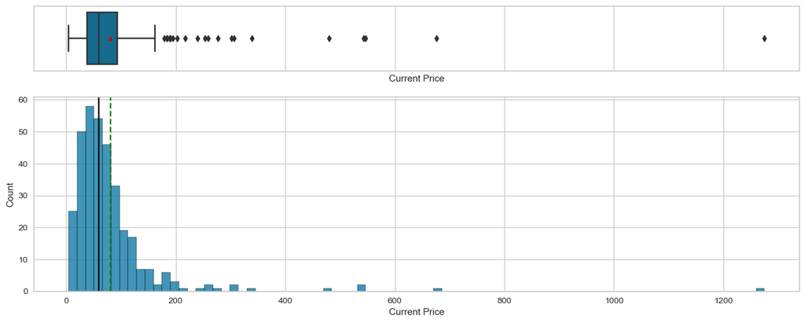

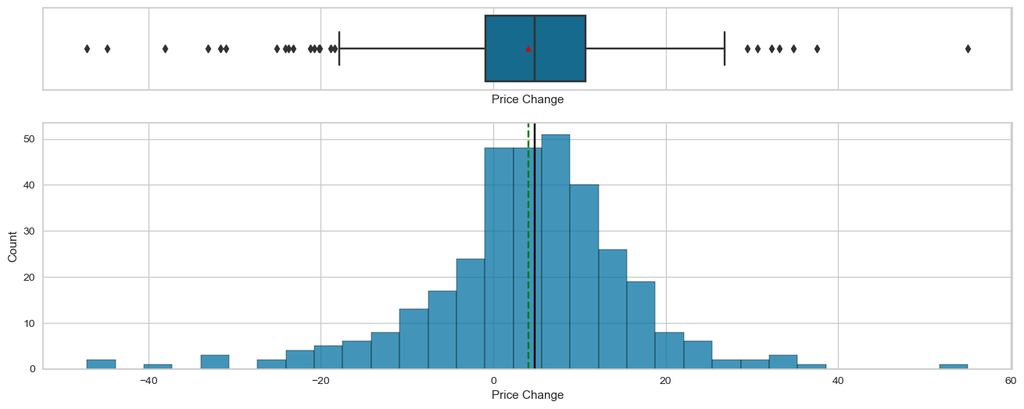

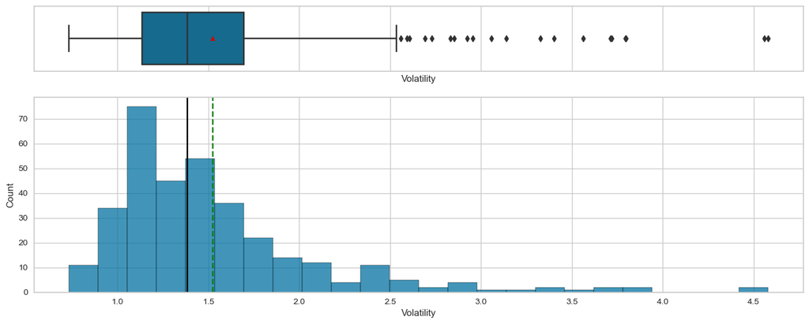

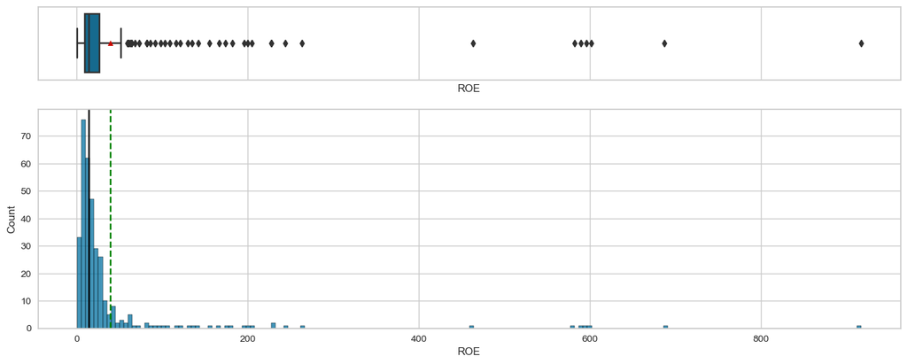

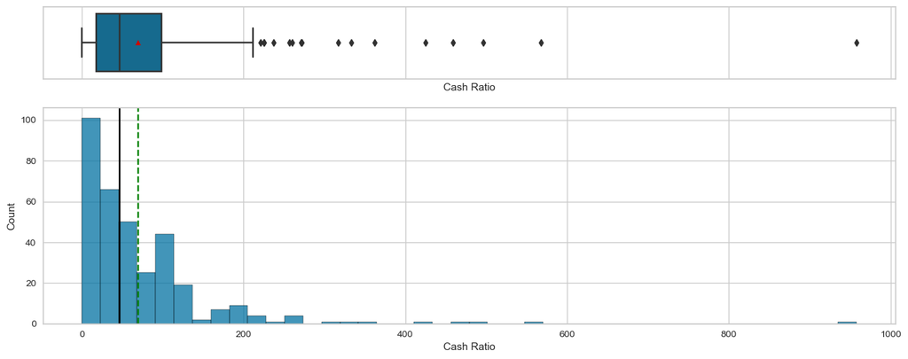

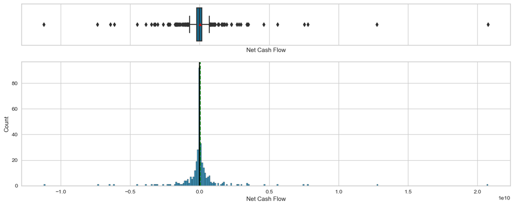

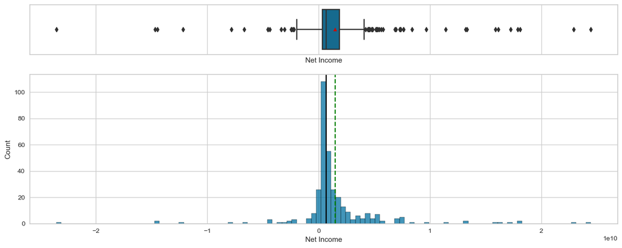

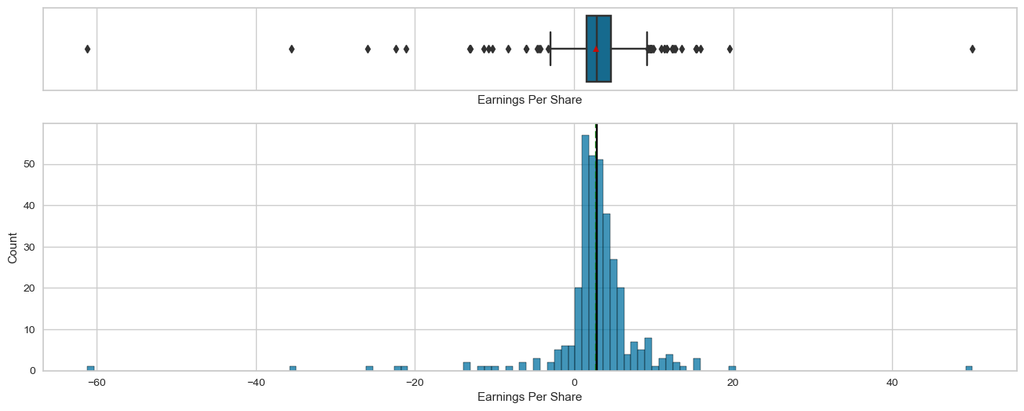

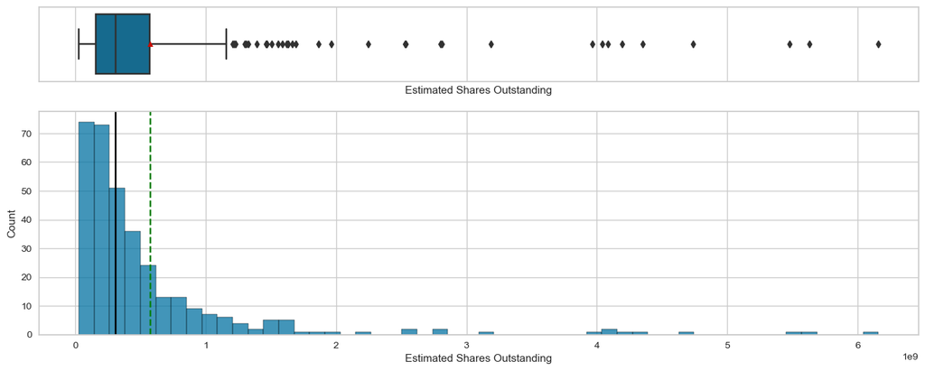

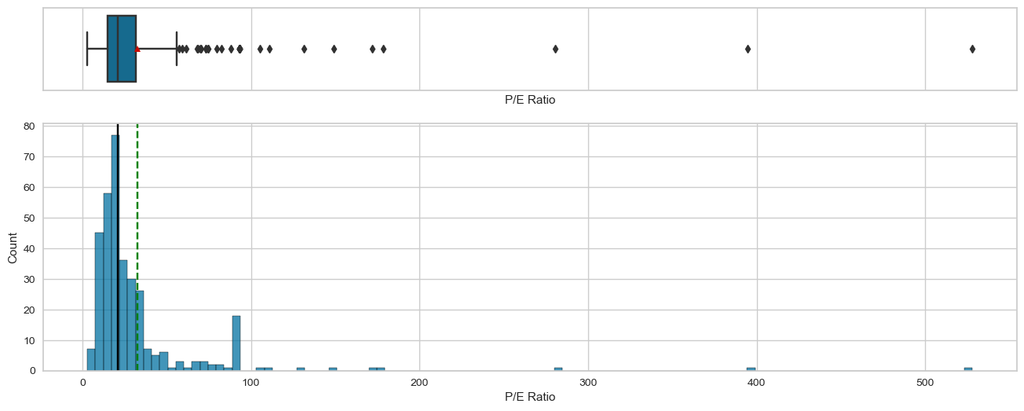

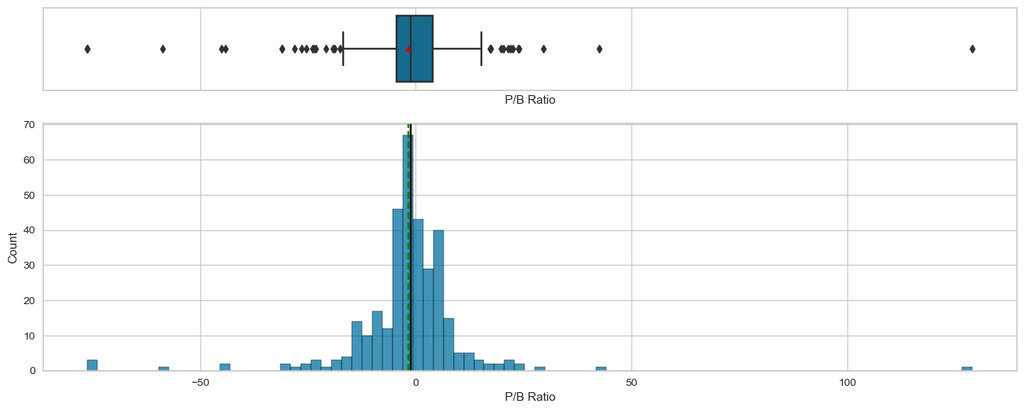

```python
#display histograms and boxplots for all numerical columns
for col in num_col:
    histogram_boxplot(data, col)
```

### Looking at each variable one at a time:

**1) Current Price**

- The distribution is right skewed.
- There are no negative value.
- There are outliers in the column.

**2) Price Change**

- The distribution of more or less normal.
- We can notice that there is some baisedness towards the lowar volatilities.
- There are some negative price changes.
- The are some outliers in the columns too.

**3) Volatility**

- The distribution is right skewed.
- There are no negaive values.
- The distribution is not normal.
- There are outliers.

**4) ROE**

- The disbtribution is highly right skewed.
- there are no negative values.

**5) Cash Ratio**

- Like ROE, Cash Ratio is also right skewed.
- Expectedly, there are no negative values.

**6) Net Cash Flow**

**7) Net Income**

- Net income is right skewed
- It has both long positive and negative tails
- What it tells us is that most companies generate meager profits
- Some are failing and some are highly successful

**8) Earnings Per Share**

- EPS is a derivative of Net Income.
- EPS has a similar distribution to Net Income.
- most stocks show low positive values and a few stocks are showing negative values

**9) Estimated Shares Outstanding**

- The distribution is highly right skewed
- no stock has a value of outstanding shares that is unrealistic

**10) P/E ratio**

- The distribution of P/E ratios is highly right skewed
- no stock shows a negative ratio

**11) P/B ratio**

- The distribution for P/B ratios is mostly centered around 0
- It has long positive and negative tails.

## The stocks of which economic sector have seen the maximum price increase on average?

```python
data.groupby('GICS Sector')['Price Change'].mean().sort_values(ascending=[False])
```

```
GICS Sector
Health Care                     9.59
Consumer Staples                8.68
Information Technology          7.22
Telecommunications Services     6.96
Real Estate                     6.21
Consumer Discretionary          5.85
Materials                       5.59
Financials                      3.87
Industrials                     2.83
Utilities                       0.80
Energy                        -10.23
Name: Price Change, dtype: float64
```

- **The stocks of 'Health Care' have shown the highest price increase on average.**
- **The 'Health Care' has shown a average price growth of 9.59.**

## How are the different variables correlated with each other?e

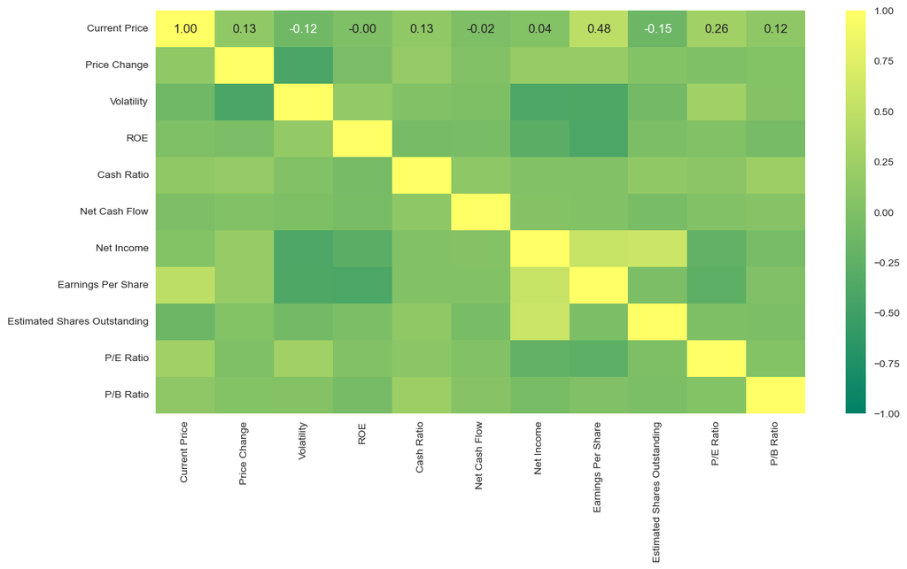

```python
#create correlation heat map for numerical variables
plt.figure(figsize=(14, 7))
sns.heatmap(
    data[num_col].corr(),
    annot=True,
    vmin=-1,
    vmax=1,
    fmt=".2f",
    cmap='summer'
)
plt.show()
```

- **Many variables are moderately correlated with one another.**
- **Net income is negatively correlayed with volatility**
- **Volatility is negatively correlated with price change**
- **EPS is positively correlated with current price and negatively correlated with ROE.**
- **Net income is also positively correlated with earnings per share (EPS) and estimated shares outstanding**

## Cash ratio provides a measure of a company's ability to cover its short-term obligations using only cash and cash equivalents. How does the average cash ratio vary across economic sectors?

```python
data.groupby('GICS Sector')['Cash Ratio'].mean().sort_values(ascending=False)
```

```
GICS Sector
Information Technology        149.82
Telecommunications Services   117.00
Health Care                   103.78
Financials                     98.59
Consumer Staples               70.95
Energy                         51.13
Real Estate                    50.11
Consumer Discretionary         49.58
Materials                      41.70
Industrials                    36.19
Utilities                      13.62
Name: Cash Ratio, dtype: float64
```

- **'Information Technology' and 'Telecommunications Services' have the highest average cash ratios.**
- **'Utilities' have the lowest average cash ratios.**

## P/E ratios can help determine the relative value of a company's shares as they signify the amount of money an investor is willing to invest in a single share of a company per dollar of its earnings. How does the P/E ratio vary, on average, across economic sectors?

```python
data.groupby('GICS Sector')['P/E Ratio'].mean().sort_values(ascending=False)
```

```
GICS Sector
Energy                        72.90
Information Technology        43.78
Real Estate                   43.07
Health Care                   41.14
Consumer Discretionary        35.21
Consumer Staples              25.52
Materials                     24.59
Utilities                     18.72
Industrials                   18.26
Financials                    16.02
Telecommunications Services   12.22
Name: P/E Ratio, dtype: float64
```

## Data Preprocessing

- Duplicate value check
- Missing value treatment
- Outlier check
- Feature engineering (if needed)
- Any other preprocessing steps (if needed)

```python
# checking for duplicated values
data.duplicated().sum()
```

```
0
```

- **There are no duplicated values in the data set**

```python
# checking is missing values

data.isnull().sum()
```

```
Security                        0
GICS Sector                     0
GICS Sub Industry               0
Current Price                   0
Price Change                    0
Volatility                      0
ROE                             0
Cash Ratio                      0
Net Cash Flow                   0
Net Income                      0
Earnings Per Share              0
Estimated Shares Outstanding    0
P/E Ratio                       0
P/B Ratio                       0
dtype: int64
```

- **There are no missing values in the dataset.**
- **We will move onto scaling the dataset now**

```python
#scale the data set before clustering

scaler = StandardScaler()
subset = data[num_col].copy()
subset_scaled = scaler.fit_transform(subset)
```

```python
#create a dataframe from the scaled data
subset_scaled_df = pd.DataFrame(subset_scaled, columns=subset.columns)
```

```python
subset_scaled_df.head()
```

|  | Current Price | Price Change | Volatility | ROE | Cash Ratio | Net Cash Flow | Net Income | Earnings Per Share | Estimated Shares Outstanding | P/E Ratio | P/B Ratio |
| --- | --- | --- | --- | --- | --- | --- | --- | --- | --- | --- | --- |
| 0 | -0.39 | 0.49 | 0.27 | 0.99 | -0.21 | -0.34 | 1.55 | 1.31 | 0.11 | -0.65 | -0.51 |
| 1 | -0.22 | 0.36 | 1.14 | 0.94 | 0.08 | -0.00 | 0.93 | 0.06 | 1.25 | -0.31 | -0.50 |
| 2 | -0.37 | 0.60 | -0.43 | -0.19 | -0.03 | 0.45 | 0.74 | 0.02 | 1.10 | -0.39 | 0.09 |
| 3 | 0.13 | 0.83 | -0.28 | -0.32 | 1.22 | -0.15 | -0.22 | -0.23 | -0.09 | 0.95 | 0.42 |
| 4 | -0.26 | -0.49 | 0.30 | -0.27 | 2.24 | 0.13 | -0.20 | -0.37 | 1.98 | 3.29 | 0.20 |

## EDA

- It is a good idea to explore the data once again after manipulating it.

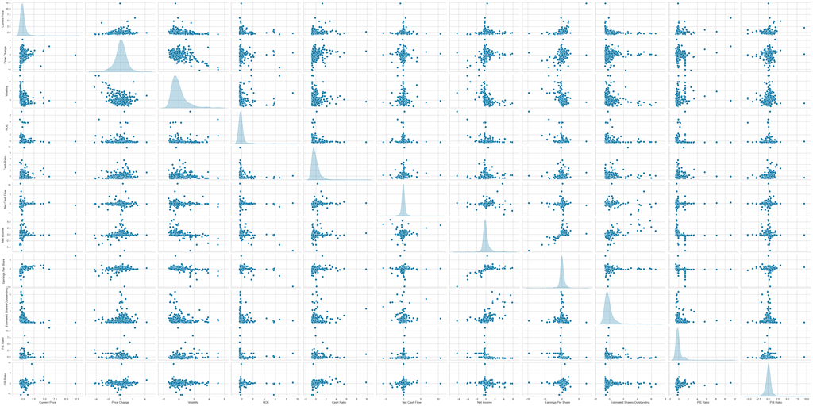

```python
#createing pairplot for scaled dataframe
sns.pairplot(subset_scaled_df, height=2,aspect=2 , diag_kind='kde')
plt.show()
```

## K-means Clustering

```
Number of Clusters: 1 	Average Distortion: 2.5425069919221697
Number of Clusters: 2 	Average Distortion: 2.382318498894466
Number of Clusters: 3 	Average Distortion: 2.2692367155390745
Number of Clusters: 4 	Average Distortion: 2.1770961257432995
Number of Clusters: 5 	Average Distortion: 2.1225218310422096
Number of Clusters: 6 	Average Distortion: 2.0756061825846586
Number of Clusters: 7 	Average Distortion: 2.051271442145359
Number of Clusters: 8 	Average Distortion: 1.985825818816722
```

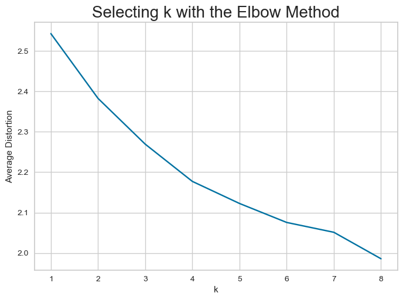

```python
clusters=range(1,9)
meanDistortions=[]

for k in clusters:
    model=KMeans(n_clusters=k)
    model.fit(subset_scaled_df)
    prediction=model.predict(subset_scaled_df)
    distortion=sum(np.min(cdist(subset_scaled_df, model.cluster_centers_, 'euclidean'), axis=1)) / subset_scaled_df.shape[0]

    meanDistortions.append(distortion)

    print('Number of Clusters:', k, '\tAverage Distortion:', distortion)

plt.plot(clusters, meanDistortions, 'bx-')
plt.xlabel('k')
plt.ylabel('Average Distortion')
plt.title('Selecting k with the Elbow Method', fontsize=20)
```

- **k seems to be either 4 or 5**

```python
# checking silhoutte score

sil_score = []
cluster_list = list(range(2,10))
for n_clusters in cluster_list:
    clusterer = KMeans(n_clusters=n_clusters)
    preds = clusterer.fit_predict((subset_scaled_df))
    #centers = clusterer.cluster_centers_
    score = silhouette_score(subset_scaled_df, preds)
    sil_score.append(score)
    print("For n_clusters = {}, silhouette score is {})".format(n_clusters, score))
```

```
For n_clusters = 2, silhouette score is 0.43969639509980457)
For n_clusters = 3, silhouette score is 0.45797710447228496)
For n_clusters = 4, silhouette score is 0.4495910932182279)
For n_clusters = 5, silhouette score is 0.4405143064564388)
For n_clusters = 6, silhouette score is 0.4118459845534201)
For n_clusters = 7, silhouette score is 0.40802535476971885)
For n_clusters = 8, silhouette score is 0.3925169378806713)
For n_clusters = 9, silhouette score is 0.40572739276418873)
```

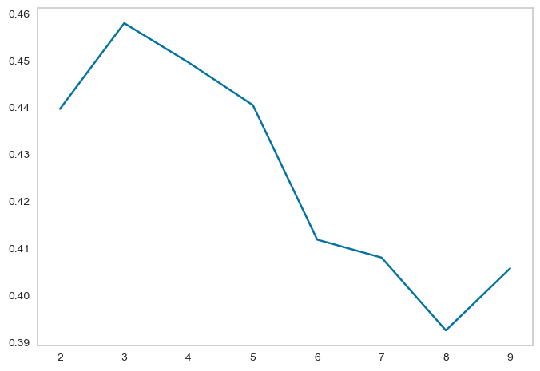

```python
plt.plot(cluster_list,sil_score)
plt.grid()
```

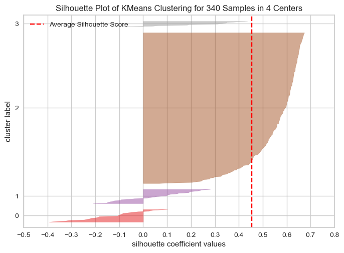

```python
# Finding optimal no. of clusters with silhouette coefficients
visualizer = SilhouetteVisualizer(KMeans(4, random_state = 1))
visualizer.fit(subset_scaled_df)
visualizer.show()
```

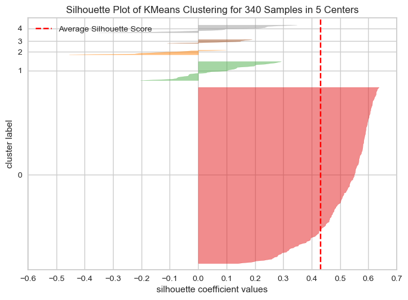

```python
visualizer = SilhouetteVisualizer(KMeans(5, random_state = 1))
visualizer.fit(subset_scaled_df)
visualizer.show()
```

```python
#create kmeans cluster model, Choosing k = 4 as the no. of clusters
kmeans = KMeans(n_clusters=4, random_state=0)

#fit model to scaled dataset
kmeans.fit(subset_scaled_df)
```

```
KMeans(n_clusters=4, random_state=0)
```

**Cluster Profiling**

```python
# adding kmeans cluster labels to the original dataframe
data["KMeans_clusters"] = kmeans.labels_
```

```python
subset_scaled_df['KMeans_clusters'] = kmeans.labels_
```

```python
data.head()
```

|  | Security | GICS Sector | GICS Sub Industry | Current Price | Price Change | Volatility | ROE | Cash Ratio | Net Cash Flow | Net Income | Earnings Per Share | Estimated Shares Outstanding | P/E Ratio | P/B Ratio | KMeans_clusters |
| --- | --- | --- | --- | --- | --- | --- | --- | --- | --- | --- | --- | --- | --- | --- | --- |
| 0 | American Airlines Group | Industrials | Airlines | 42.35 | 10.00 | 1.69 | 135 | 51 | -604000000 | 7610000000 | 11.39 | 668129938.50 | 3.72 | -8.78 | 0 |
| 1 | AbbVie | Health Care | Pharmaceuticals | 59.24 | 8.34 | 2.20 | 130 | 77 | 51000000 | 5144000000 | 3.15 | 1633015873.00 | 18.81 | -8.75 | 0 |
| 2 | Abbott Laboratories | Health Care | Health Care Equipment | 44.91 | 11.30 | 1.27 | 21 | 67 | 938000000 | 4423000000 | 2.94 | 1504421769.00 | 15.28 | -0.39 | 0 |
| 3 | Adobe Systems Inc | Information Technology | Application Software | 93.94 | 13.98 | 1.36 | 9 | 180 | -240840000 | 629551000 | 1.26 | 499643650.80 | 74.56 | 4.20 | 0 |
| 4 | Analog Devices, Inc. | Information Technology | Semiconductors | 55.32 | -1.83 | 1.70 | 14 | 272 | 315120000 | 696878000 | 0.31 | 2247993548.00 | 178.45 | 1.06 | 2 |

```python
subset_scaled_df.head()
```

|  | Current Price | Price Change | Volatility | ROE | Cash Ratio | Net Cash Flow | Net Income | Earnings Per Share | Estimated Shares Outstanding | P/E Ratio | P/B Ratio | KMeans_clusters |
| --- | --- | --- | --- | --- | --- | --- | --- | --- | --- | --- | --- | --- |
| 0 | -0.39 | 0.49 | 0.27 | 0.99 | -0.21 | -0.34 | 1.55 | 1.31 | 0.11 | -0.65 | -0.51 | 0 |
| 1 | -0.22 | 0.36 | 1.14 | 0.94 | 0.08 | -0.00 | 0.93 | 0.06 | 1.25 | -0.31 | -0.50 | 0 |
| 2 | -0.37 | 0.60 | -0.43 | -0.19 | -0.03 | 0.45 | 0.74 | 0.02 | 1.10 | -0.39 | 0.09 | 0 |
| 3 | 0.13 | 0.83 | -0.28 | -0.32 | 1.22 | -0.15 | -0.22 | -0.23 | -0.09 | 0.95 | 0.42 | 0 |
| 4 | -0.26 | -0.49 | 0.30 | -0.27 | 2.24 | 0.13 | -0.20 | -0.37 | 1.98 | 3.29 | 0.20 | 2 |

```python
#group dataset by kmeans cluster labels
cluster_profile = data.groupby('KMeans_clusters').mean(numeric_only = True)

#add counts for number of stocks in each cluster
cluster_profile['count'] = data.groupby('KMeans_clusters')['Security'].count().values
```

```python
cluster_profile.style.highlight_max(color="lightblue", axis=0)
```

| KMeans_clusters | Current Price | Price Change | Volatility | ROE | Cash Ratio | Net Cash Flow | Net Income | Earnings Per Share | Estimated Shares Outstanding | P/E Ratio | P/B Ratio | count |
| --- | --- | --- | --- | --- | --- | --- | --- | --- | --- | --- | --- | --- |
| 0 | 72.470050 | 5.059104 | 1.388717 | 34.710145 | 52.938406 | -18021028.985507 | 1471488521.739130 | 3.628424 | 429936522.010181 | 23.808921 | -3.355600 | 276 |
| 1 | 35.165385 | -16.390175 | 2.922214 | 110.961538 | 49.461538 | -192318884.615385 | -4041692307.692307 | -9.849231 | 482610056.416923 | 78.934814 | 1.612922 | 26 |
| 2 | 238.072932 | 13.508882 | 1.777479 | 25.600000 | 276.280000 | 752195440.000000 | 941997320.000000 | 5.889600 | 561429538.460800 | 90.217183 | 14.211965 | 25 |
| 3 | 48.103077 | 6.053507 | 1.163964 | 27.538462 | 77.230769 | 773230769.230769 | 14114923076.923077 | 3.958462 | 3918734987.169230 | 16.098039 | -4.253404 | 13 |

```python
# print the names of the companies in each cluster
for cl in data["KMeans_clusters"].unique():
    print("In cluster {}, the following companies are present:".format(cl))
    print(data[data["KMeans_clusters"] == cl]["Security"].unique().to_list())
    print()
```

```
In cluster 0, the following companies are present:
['American Airlines Group', 'AbbVie', 'Abbott Laboratories', 'Adobe Systems Inc', 'Archer-Daniels-Midland Co', 'Ameren Corp', 'American Electric Power', 'AFLAC Inc', 'American International Group, Inc.', 'Apartment Investment & Mgmt', 'Assurant Inc', 'Arthur J. Gallagher & Co.', 'Akamai Technologies…

In cluster 2, the following companies are present:
['Analog Devices, Inc.', 'Alliance Data Systems', 'Alexion Pharmaceuticals', 'Amgen Inc', 'Amazon.com Inc', 'BIOGEN IDEC Inc.', 'Celgene Corp.', 'Chipotle Mexican Grill', 'Equinix', 'Edwards Lifesciences', 'Facebook', 'First Solar Inc', 'Frontier Communications', 'Halliburton Co.', 'Intuitive Surgic…

In cluster 1, the following companies are present:
['Apache Corporation', 'Anadarko Petroleum Corp', 'Baker Hughes Inc', 'Chesapeake Energy', 'Cabot Oil & Gas', 'Concho Resources', 'Devon Energy Corp.', 'EOG Resources', 'EQT Corporation', 'Freeport-McMoran Cp & Gld', 'Hess Corporation', 'Hewlett Packard Enterprise', 'Kinder Morgan', 'Marathon Oil Co…

In cluster 3, the following companies are present:
['Bank of America Corp', 'Citigroup Inc.', 'Ford Motor', 'Gilead Sciences', 'Intel Corp.', 'JPMorgan Chase & Co.', 'Coca Cola Company', 'Merck & Co.', 'Pfizer Inc.', 'AT&T Inc', 'Verizon Communications', 'Wells Fargo', 'Exxon Mobil Corp.']
```

```python
# Comparing cluster vs. GICS_Sector

pd.crosstab(data['GICS Sector'], data['KMeans_clusters']).style.highlight_max(color = 'yellow', axis = 0)
```

| KMeans_clusters GICS Sector | 0 | 1 | 2 | 3 |
| --- | --- | --- | --- | --- |
| Consumer Discretionary | 33 | 0 | 6 | 1 |
| Consumer Staples | 17 | 0 | 1 | 1 |
| Energy | 6 | 22 | 1 | 1 |
| Financials | 45 | 0 | 0 | 4 |
| Health Care | 28 | 0 | 9 | 3 |
| Industrials | 52 | 1 | 0 | 0 |
| Information Technology | 24 | 2 | 6 | 1 |
| Materials | 19 | 1 | 0 | 0 |
| Real Estate | 26 | 0 | 1 | 0 |
| Telecommunications Services | 2 | 0 | 1 | 2 |
| Utilities | 24 | 0 | 0 | 0 |

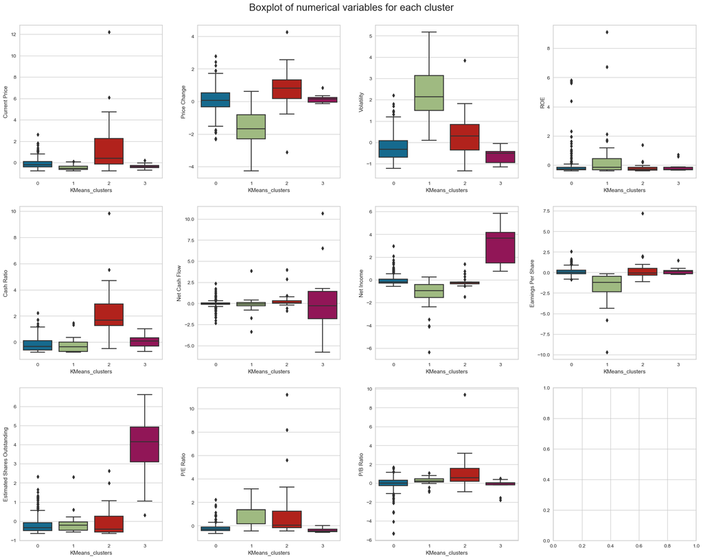

```python
fig, axes = plt.subplots(3, 4,  figsize=(20, 16))
fig.suptitle('Boxplot of numerical variables for each cluster', fontsize=20)
counter = 0
for ii in range(3):
    for jj in range(4):
        if counter <11:
            sns.boxplot(ax=axes[ii, jj],y=subset_scaled_df[num_col[counter]],x=subset_scaled_df['KMeans_clusters'])
        counter = counter+1

fig.tight_layout(pad=2.0)
```

```python
#print number of stocks within each sector for all of the clusters
for k in range(0,data['KMeans_clusters'].nunique()):
    print('The number of stocks within each GICS Sector for Cluster '+str(k)+' are:')
    print(data[data['KMeans_clusters']==k]['GICS Sector'].value_counts())
    print("   ")
```

```
The number of stocks within each GICS Sector for Cluster 0 are:
GICS Sector
Industrials                    52
Financials                     45
Consumer Discretionary         33
Health Care                    28
Real Estate                    26
Information Technology         24
Utilities                      24
Materials                      19
Consumer Staples               17
Energy                          6
Telecommunications Services     2
Name: count, dtype: int64

The number of stocks within each GICS Sector for Cluster 1 are:
GICS Sector
Energy                         22
Information Technology          2
Industrials                     1
Materials                       1
Consumer Discretionary          0
Consumer Staples                0
Financials                      0
Health Care                     0
Real Estate                     0
Telecommunications Services     0
Utilities                       0
Name: count, dtype: int64

The number of stocks within each GICS Sector for Cluster 2 are:
GICS Sector
Health Care                    9
Consumer Discretionary         6
Information Technology         6
Consumer Staples               1
Energy                         1
Real Estate                    1
Telecommunications Services    1
Financials                     0
Industrials                    0
Materials                      0
Utilities                      0
Name: count, dtype: int64

The number of stocks within each GICS Sector for Cluster 3 are:
GICS Sector
Financials                     4
Health Care                    3
Telecommunications Services    2
Consumer Discretionary         1
Consumer Staples               1
Energy                         1
Information Technology         1
Industrials                    0
Materials                      0
Real Estate                    0
Utilities                      0
Name: count, dtype: int64
```

### Insights

Cluster 0

Has the majority of securities at 276

Volatility of this cluster is intermediate

Cluster 1

Has about 26 different securities

Volatility of the cluster is on the higher side

Cluster 2

Has about 25 different securities

Volatility of this cluster is intermediate

Cluster 3

Has securities with some of the highest Estimated_Shares_Outstanding

## Hierarchical Clustering

```python
# list of distance metrics
distance_metrics = ["euclidean", "chebyshev", "mahalanobis", "cityblock"]

# list of linkage methods
linkage_methods = ["single", "complete", "average", "weighted"]

high_cophenet_corr = 0
high_dm_lm = [0, 0]

for dm in distance_metrics:
    for lm in linkage_methods:
        Z = linkage(subset_scaled_df, metric=dm, method=lm)
        c, coph_dists = cophenet(Z, pdist(subset_scaled_df))
        print(
            "Cophenetic correlation for {} distance and {} linkage is {}.".format(
                dm.capitalize(), lm, round(c,4)
            )
        )
        print(" ")
        if high_cophenet_corr < c:
            high_cophenet_corr = c
            high_dm_lm[0] = dm
            high_dm_lm[1] = lm
```

```
Cophenetic correlation for Euclidean distance and single linkage is 0.9316.

Cophenetic correlation for Euclidean distance and complete linkage is 0.8318.

Cophenetic correlation for Euclidean distance and average linkage is 0.9412.

Cophenetic correlation for Euclidean distance and weighted linkage is 0.9183.

Cophenetic correlation for Chebyshev distance and single linkage is 0.9179.

Cophenetic correlation for Chebyshev distance and complete linkage is 0.8028.

Cophenetic correlation for Chebyshev distance and average linkage is 0.933.

Cophenetic correlation for Chebyshev distance and weighted linkage is 0.9122.

Cophenetic correlation for Mahalanobis distance and single linkage is 0.9291.

Cophenetic correlation for Mahalanobis distance and complete linkage is 0.8151.

Cophenetic correlation for Mahalanobis distance and average linkage is 0.9355.

Cophenetic correlation for Mahalanobis distance and weighted linkage is 0.8961.

Cophenetic correlation for Cityblock distance and single linkage is 0.9245.

Cophenetic correlation for Cityblock distance and complete linkage is 0.6451.

Cophenetic correlation for Cityblock distance and average linkage is 0.908.

Cophenetic correlation for Cityblock distance and weighted linkage is 0.6457.
```

```python
# printing the combination of distance metric and linkage method with the highest cophenetic correlation
print(
    "Highest cophenetic correlation is {}, which is obtained with {} distance and {} linkage".format(
        high_cophenet_corr, high_dm_lm[0].capitalize(), high_dm_lm[1]
    )
)
```

```
Highest cophenetic correlation is 0.941150484500575, which is obtained with Euclidean distance and average linkage
```

```python
# list of linkage methods for euclidean distance metric
linkage_methods = ["single", "complete", "average", "centroid", "ward", "weighted"]

high_cophenet_corr = 0
high_dm_lm = [0, 0]

for lm in linkage_methods:
    Z = linkage(subset_scaled_df, metric="euclidean", method=lm)
    c, coph_dists = cophenet(Z, pdist(subset_scaled_df))
    print(
            "Cophenetic correlation for Euclidean distance and {} linkage is {}.".format(
                lm, round(c,4)
            )
        )
    print(" ")
    if high_cophenet_corr < c:
        high_cophenet_corr = c
        high_dm_lm[0] = "euclidean"
        high_dm_lm[1] = lm
```

```
Cophenetic correlation for Euclidean distance and single linkage is 0.9316.

Cophenetic correlation for Euclidean distance and complete linkage is 0.8318.

Cophenetic correlation for Euclidean distance and average linkage is 0.9412.

Cophenetic correlation for Euclidean distance and centroid linkage is 0.9397.

Cophenetic correlation for Euclidean distance and ward linkage is 0.7524.

Cophenetic correlation for Euclidean distance and weighted linkage is 0.9183.
```

```python
# printing the combination of distance metric and linkage method with the highest cophenetic correlation
print(
    "Highest cophenetic correlation is {}, which is obtained with {} linkage.".format(
        round(high_cophenet_corr,4), high_dm_lm[1]
    )
)
```

```
Highest cophenetic correlation is 0.9412, which is obtained with average linkage.
```

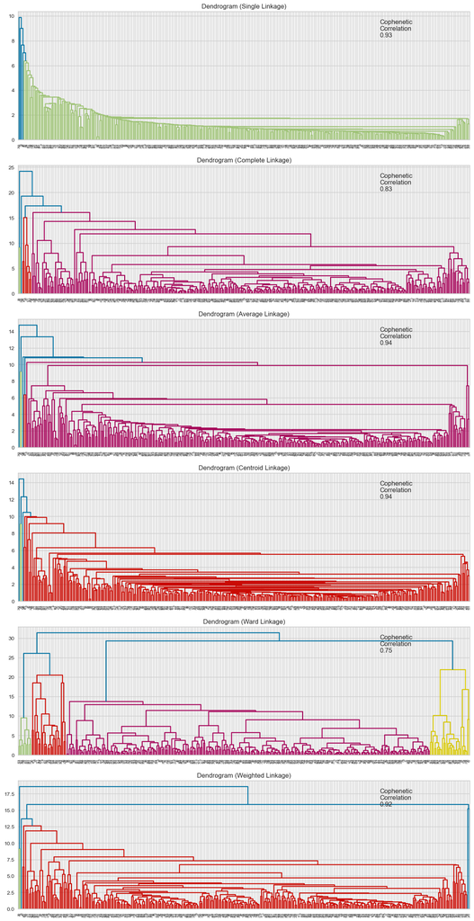

```python
# list of linkage methods
linkage_methods = ["single", "complete", "average", "centroid", "ward", "weighted"]

# lists to save results of cophenetic correlation calculation
compare_cols = ["Linkage", "Cophenetic Coefficient"]

# to create a subplot image
fig, axs = plt.subplots(len(linkage_methods), 1, figsize=(15, 30))

# We will enumerate through the list of linkage methods above
# For each linkage method, we will plot the dendrogram and calculate the cophenetic correlation
for i, method in enumerate(linkage_methods):
    Z = linkage(subset_scaled_df, metric="euclidean", method=method)

    dendrogram(Z, ax=axs[i])
    axs[i].set_title(f"Dendrogram ({method.capitalize()} Linkage)")

    coph_corr, coph_dist = cophenet(Z, pdist(subset_scaled_df))
    axs[i].annotate(
        f"Cophenetic\nCorrelation\n{coph_corr:0.2f}",
        (0.80, 0.80),
        xycoords="axes fraction",
    )
```

- **Cophenetic correlation is highest with eucledian distance & average or centroid linkages**
- **6 appears to be the appropriate number of clusters from the dendrogram for average linkage**

```python
HCmodel = AgglomerativeClustering(n_clusters=6, affinity="euclidean", linkage="average")
HCmodel.fit(subset_scaled_df)
```

```
AgglomerativeClustering(affinity='euclidean', linkage='average', n_clusters=6)
```

**Cluster Profiling**

```python
subset_scaled_df["HC_Clusters"] = HCmodel.labels_
data["HC_Clusters"] = HCmodel.labels_
```

```python
cluster_profile_h = data.groupby("HC_Clusters").mean(numeric_only = True)
```

```python
cluster_profile_h["count_in_each_segments"] = (
    data.groupby("HC_Clusters")["Security"].count().values
)
```

```python
cluster_profile_h.style.highlight_max(color="lightblue", axis=0)
```

| HC_Clusters | Current Price | Price Change | Volatility | ROE | Cash Ratio | Net Cash Flow | Net Income | Earnings Per Share | Estimated Shares Outstanding | P/E Ratio | P/B Ratio | KMeans_clusters | count_in_each_segments |
| --- | --- | --- | --- | --- | --- | --- | --- | --- | --- | --- | --- | --- | --- |
| 0 | 77.287589 | 4.099730 | 1.518066 | 35.336336 | 66.900901 | -33197321.321321 | 1538074666.666667 | 2.885270 | 560505037.293544 | 32.441706 | -2.174921 | 0.303303 | 333 |
| 1 | 25.640000 | 11.237908 | 1.322355 | 12.500000 | 130.500000 | 16755500000.000000 | 13654000000.000000 | 3.295000 | 2791829362.100000 | 13.649696 | 1.508484 | 3.000000 | 2 |
| 2 | 24.485001 | -13.351992 | 3.482611 | 802.000000 | 51.000000 | -1292500000.000000 | -19106500000.000000 | -41.815000 | 519573983.250000 | 60.748608 | 1.565141 | 1.000000 | 2 |
| 3 | 104.660004 | 16.224320 | 1.320606 | 8.000000 | 958.000000 | 592000000.000000 | 3669000000.000000 | 1.310000 | 2800763359.000000 | 79.893133 | 5.884467 | 2.000000 | 1 |
| 4 | 1274.949951 | 3.190527 | 1.268340 | 29.000000 | 184.000000 | -1671386000.000000 | 2551360000.000000 | 50.090000 | 50935516.070000 | 25.453183 | -1.052429 | 2.000000 | 1 |
| 5 | 276.570007 | 6.189286 | 1.116976 | 30.000000 | 25.000000 | 90885000.000000 | 596541000.000000 | 8.910000 | 66951851.850000 | 31.040405 | 129.064585 | 2.000000 | 1 |

- **Of the six cluster, five clusters have two, two, one, one, and one security.**
- **The lack of sufficient variety inside the clusters makes this grouping appear unsatisfactory.**
- **We will try using Ward linkage this time because it has more distinct and separated clusters (as shown from its previous dendrogram).**
- **It seems that four clusters from the dendrogram are sufficient for Ward linkage.**

```python
HCmodel = AgglomerativeClustering(n_clusters=4, affinity="euclidean", linkage="ward")
HCmodel.fit(subset_scaled_df)
```

```
AgglomerativeClustering(affinity='euclidean', n_clusters=4)
```

```python
subset_scaled_df["HC_Clusters"] = HCmodel.labels_
data["HC_Clusters"] = HCmodel.labels_
```

```python
#group dataset by Hierarchical clusters
cluster_profile_h = data.groupby("HC_Clusters").mean(numeric_only=True)
```

```python
#add counts for number of stocks in each cluster
cluster_profile_h["Count"] = (
    data.groupby("HC_Clusters")["Current Price"].count().values
)
```

```python
#show dataframe with maximum values for each metric highlighted
cluster_profile_h.style.highlight_max(color="aqua", axis=0)
```

| HC_Clusters | Current Price | Price Change | Volatility | ROE | Cash Ratio | Net Cash Flow | Net Income | Earnings Per Share | Estimated Shares Outstanding | P/E Ratio | P/B Ratio | KMeans_clusters | Count |
| --- | --- | --- | --- | --- | --- | --- | --- | --- | --- | --- | --- | --- | --- |
| 0 | 47.081001 | -11.442082 | 2.602381 | 190.333333 | 39.300000 | -481429800.000000 | -3466609033.333333 | -8.347000 | 476856000.764667 | 73.031755 | -1.947472 | 0.800000 | 30 |
| 1 | 221.688588 | 13.964266 | 1.722450 | 27.730769 | 269.000000 | 1815576384.615385 | 2541920500.000000 | 5.831154 | 769356542.223846 | 83.765432 | 13.229503 | 2.115385 | 26 |
| 2 | 72.423335 | 4.792872 | 1.405051 | 24.806569 | 54.890511 | 45268974.452555 | 1488763149.635036 | 3.687464 | 430600922.608066 | 23.889134 | -2.949916 | 0.021898 | 274 |
| 3 | 47.287000 | 5.353050 | 1.099277 | 23.500000 | 59.500000 | -2628300000.000000 | 13807800000.000000 | 3.250000 | 4389603192.100000 | 17.379484 | -6.147066 | 3.000000 | 10 |

- **Now the cluster grouping appears more fitting.**

```python
# print the names of the companies in each cluster
for cl in data["HC_Clusters"].unique():
    print("In cluster {}, the following companies are present:".format(cl))
    print(data[data["HC_Clusters"] == cl]["Security"].unique().tolist())
    print()
```

```
In cluster 2, the following companies are present:
['American Airlines Group', 'AbbVie', 'Abbott Laboratories', 'Adobe Systems Inc', 'Archer-Daniels-Midland Co', 'Ameren Corp', 'American Electric Power', 'AFLAC Inc', 'American International Group, Inc.', 'Apartment Investment & Mgmt', 'Assurant Inc', 'Arthur J. Gallagher & Co.', 'Akamai Technologies…

In cluster 1, the following companies are present:
['Analog Devices, Inc.', 'Alliance Data Systems', 'Alexion Pharmaceuticals', 'Amgen Inc', 'Amazon.com Inc', 'Bank of America Corp', 'Celgene Corp.', 'Chipotle Mexican Grill', 'Equinix', 'Edwards Lifesciences', 'Facebook', 'First Solar Inc', 'Frontier Communications', 'Gilead Sciences', 'Intel Corp.'…

In cluster 0, the following companies are present:
['Allegion', 'Apache Corporation', 'Anadarko Petroleum Corp', 'Baker Hughes Inc', 'Chesapeake Energy', 'Charter Communications', 'Colgate-Palmolive', 'Cabot Oil & Gas', 'Concho Resources', 'Devon Energy Corp.', 'EOG Resources', 'Freeport-McMoran Cp & Gld', 'Hess Corporation', 'Kimberly-Clark', 'Kind…

In cluster 3, the following companies are present:
['Citigroup Inc.', 'Ford Motor', 'JPMorgan Chase & Co.', 'Coca Cola Company', 'Merck & Co.', 'Pfizer Inc.', 'AT&T Inc', 'Verizon Communications', 'Wells Fargo', 'Exxon Mobil Corp.']
```

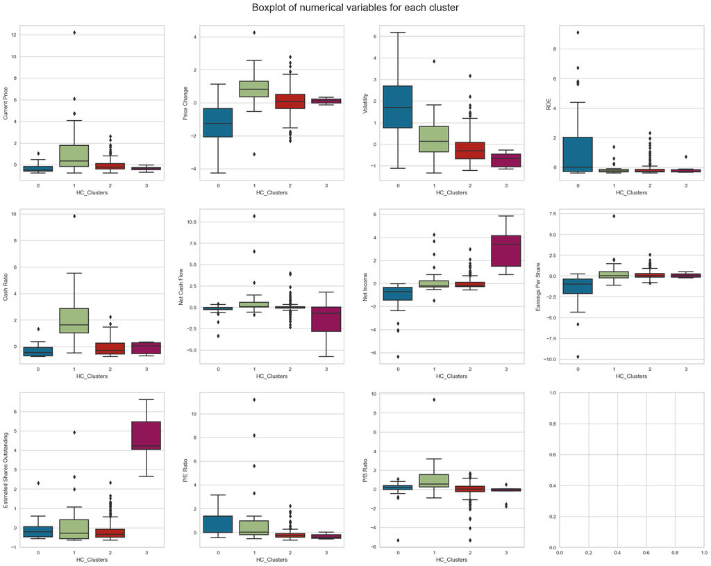

```python
fig, axes = plt.subplots(3, 4,  figsize=(20, 16))
fig.suptitle('Boxplot of numerical variables for each cluster', fontsize=20)
counter = 0
for ii in range(3):
    for jj in range(4):
        if counter <11:
            sns.boxplot(ax=axes[ii, jj],y=subset_scaled_df[num_col[counter]],x=subset_scaled_df['HC_Clusters'])
        counter = counter+1

fig.tight_layout(pad=2.0)
```

```python
# print the number of stocks in each GICS sector for each cluster
for k in range(0,data['HC_Clusters'].nunique()):
    print('The number of stocks within each GICS Sector for Cluster '+str(k)+' are:')
    print(data[data['HC_Clusters']==k]['GICS Sector'].value_counts())
    print("   ")
```

```
The number of stocks within each GICS Sector for Cluster 0 are:
GICS Sector
Energy                         22
Consumer Staples                2
Industrials                     2
Consumer Discretionary          1
Financials                      1
Information Technology          1
Materials                       1
Health Care                     0
Real Estate                     0
Telecommunications Services     0
Utilities                       0
Name: count, dtype: int64

The number of stocks within each GICS Sector for Cluster 1 are:
GICS Sector
Health Care                    9
Information Technology         7
Consumer Discretionary         6
Consumer Staples               1
Financials                     1
Real Estate                    1
Telecommunications Services    1
Energy                         0
Industrials                    0
Materials                      0
Utilities                      0
Name: count, dtype: int64

The number of stocks within each GICS Sector for Cluster 2 are:
GICS Sector
Industrials                    51
Financials                     44
Consumer Discretionary         32
Health Care                    29
Real Estate                    26
Information Technology         25
Utilities                      24
Materials                      19
Consumer Staples               15
Energy                          7
Telecommunications Services     2
Name: count, dtype: int64

The number of stocks within each GICS Sector for Cluster 3 are:
GICS Sector
Financials                     3
Health Care                    2
Telecommunications Services    2
Consumer Discretionary         1
Consumer Staples               1
Energy                         1
Industrials                    0
Information Technology         0
Materials                      0
Real Estate                    0
Utilities                      0
Name: count, dtype: int64
```

### Insights

Cluster 0

Similar to cluster 1 in Kmeans

Cluster 1

Similar to cluster 2 in Kmeans

Cluster 2

Similar to cluster 0 in Kmeans

Cluster 3

Similar to cluster 3 in Kmeans

## K-means vs Hierarchical Clustering

You compare several things, like:

- Which clustering technique took less time for execution?
- Which clustering technique gave you more distinct clusters, or are they the same?
- How many observations are there in the similar clusters of both algorithms?
- How many clusters are obtained as the appropriate number of clusters from both algorithms?

You can also mention any differences or similarities you obtained in the cluster profiles from both the clustering techniques.

```python
# Comparing Hierarchical cluster vs. K-means  cluster

pd.crosstab(data['KMeans_clusters'], data['HC_Clusters'])
```

| HC_Clusters KMeans_clusters | 0 | 1 | 2 | 3 |
| --- | --- | --- | --- | --- |
| 0 | 6 | 0 | 270 | 0 |
| 1 | 24 | 0 | 2 | 0 |
| 2 | 0 | 23 | 2 | 0 |
| 3 | 0 | 3 | 0 | 10 |

### Which clustering technique gave you more distinct clusters, or are they the same? How many observations are there in the similar clusters of both algorithms?

```python
# Dimensionality Reduction using PCA for visualization
# PCA to reduce the data to two dimensions and visualize it to see how well-separated the clusters are

# setting the number of components to 2
pca = PCA(n_components=2)

# transforming data and storing results in a dataframe
X_reduced_pca = pca.fit_transform(subset_scaled_df)
reduced_df_pca = pd.DataFrame(
    data=X_reduced_pca, columns=["Component 1", "Component 2"]
)
```

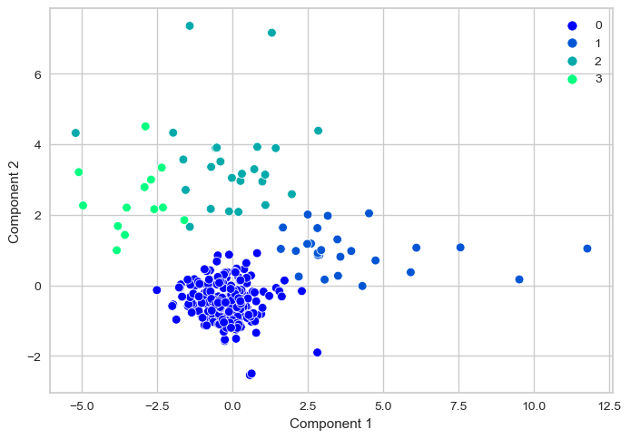

```python
# scatterplot using K-Means
sns.scatterplot(
    data=reduced_df_pca,
    x="Component 1",
    y="Component 2",
    hue=data["KMeans_clusters"],
    palette="winter",
)
plt.legend(bbox_to_anchor=(1, 1))
```

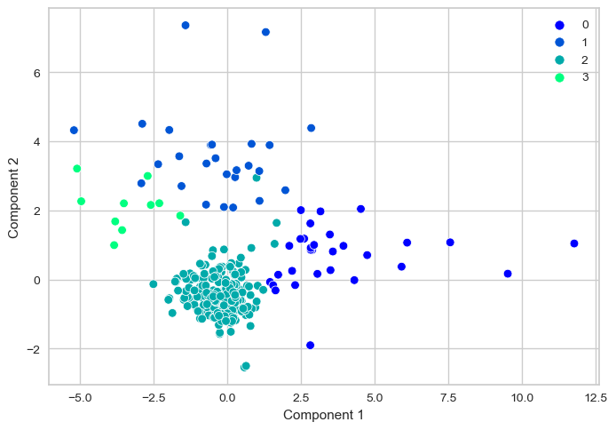

```python
#Scatterplot of the Hierarchial Clustering
sns.scatterplot(
    data=reduced_df_pca,
    x="Component 1",
    y="Component 2",
    hue=data["HC_Clusters"],
    palette="winter",
)
plt.legend(bbox_to_anchor=(1, 1))
```

- **With one cluster holding the majority of the data points and the other clusters capturing the outliers, the four clusters are pretty neatly divided.**
- **Although there are some minor variations between the plots produced by hierarchical and K-Means clustering, overall, the resulting clusters are more or less similar**

### How many clusters are obtained as the appropriate number of clusters from both algorithms?

- **For both algorithms, 4 clusters provided distinct clusters with sufficient observations in each to reasonably differentiate which "type" of stock is representative of the cluster**

### Differences or similarities in the cluster profiles from both the clustering techniques

- **Based on the outliers within the 11 variables, both algorithms produced clusters that were comparable.**

## Actionable Insights and Recommendations

- Trade&Ahead should first ascertain its clients' financial objectives, risk tolerance, and investment habits before suggesting a cluster as a possible stock portfolio that satisfies these requirements.
- To find very aggressive (high & low performing), moderately aggressive (& high performing), and slightly aggressive options, securities were divided into 4 clusters.
- This is crucial in an attempt to divide the stocks among varied assets, allowing one to optimize profits in any state of the market.
- These clusters could serve as a jumping off point for additional financial statement analysis by Trade&Ahead, allowing it to identify specific stocks that do not match the "profile" of the cluster.